# SAMSI Undergraduate Research Workshop 2020

Ernest Fokoue

This segment of the course provides a step by step introduction to some of the most foundational concepts of statistical machine learning, namely cross validation and the related stochastic hold out for comparing different statistical learning machines. The beautiful graphical tool known as Receiver Operating Characteristic Curve (ROC) is introduced. All these concepts are introduced using k Nearest Neighbors Learning Machines.

Let’s get started right here

```r
# Loading the libraries needed
  library(tuneR)
  library(audio)
  library(signal)
  library(MASS)
  library(kernlab)
  library(mclust)
  library(mixtools)
  library(dtw)
  library(mvtnorm)
  library(sound)

# Start here

  # Point to the directory where the files are stored
  where <- "AccentRecognition"
  filename <- dir(where)[-1]
  n        <- length(filename)
  # Set the media player from your operating system to play the audio

  setWavPlayer("C:/Program Files/Window Media Player/wmplayer.exe")
```

```
[1] "WAV file player 'C:/Program Files/Window Media Player/wmplayer.exe' linked successfully."
```

```r
  #somesounds <- sample(sample(sample(n)))[1:9]
```

Let’s now pick only a few of the soundtracks

```r
   somesounds <- c(78, 282, 278, 210, 329,  44,  15,  90, 194)

   graphics.off()
   for (i in somesounds)
   {

    track <- readWave(paste0(where,'/',filename[i]))
    plot(track, main='')
    plot(track, main=substr(filename[i],1,4))

  }
```

[output not shown]

What do some of the sounds sound like?

```r
  fokoue <- readWave('fokoue-intro-sml-1.wav')
  plot(fokoue, main='')
  plot(fokoue, main='Fokoue, Ernest')
  play(load.wave('fokoue-intro-sml-1.wav'))
```

[output not shown]

How about hearing some of the sounds we will be analyzing thoroughly?

```r
  par(mfrow=c(3,3))
  for (i in somesounds)
  {

   track <- readWave(paste0(where,'/',filename[i]))
   plot(track, main=substr(filename[i],1,4))
   play(load.wave(paste0(where,'/',filename[i])))
  }
```

[output not shown]

## Dataset used in this segment

We can now upload the data segment for this lab and explore it in ample details

```r
  accent <- read.csv('accent-mfcc-data-1.csv', header=T)

  xy   <- accent
  x    <- accent[,-1]
  MFCC <- x
  y    <- xy[,1]

  n    <- nrow(xy)
  p    <- ncol(xy)-1

  head(xy)
```

|  | language | X1 | X2 | X3 | X4 | X5 | X6 | X7 | X8 | X9 | X10 | X11 | X12 |
| --- | --- | --- | --- | --- | --- | --- | --- | --- | --- | --- | --- | --- | --- |
| 1 | ES | 7.071476 | -6.512900 | 7.650800 | 11.150783 | -7.657312 | 12.484021 | -11.70977 | 3.426596 | 1.4627152 | -2.812753 | 0.8665378 | -5.244274 |
| 2 | ES | 10.982967 | -5.157445 | 3.952060 | 11.529381 | -7.638047 | 12.136098 | -12.03625 | 3.491943 | 0.5954408 | -4.508811 | 2.3321470 | -6.221857 |
| 3 | ES | 7.827108 | -5.477472 | 7.816257 | 9.187592 | -7.172511 | 11.715299 | -13.84721 | 4.574075 | -1.6875593 | -7.204041 | -0.0118469 | -6.463144 |
| 4 | ES | 6.744083 | -5.688920 | 6.546789 | 9.000183 | -6.924963 | 11.710766 | -12.37439 | 6.169879 | -0.5447467 | -6.019237 | 1.3585595 | -6.356441 |
| 5 | ES | 5.836843 | -5.326557 | 7.472265 | 8.847440 | -6.773244 | 12.677218 | -12.31506 | 4.416344 | 0.1934999 | -3.644812 | 2.1512386 | -6.816310 |
| 6 | ES | 6.267089 | -4.227738 | 7.227741 | 10.069418 | -6.953871 | 9.384771 | -15.34154 | 6.718533 | -0.4509516 | -7.177585 | 2.5387129 | -3.550536 |

```r
  n; p
```

```
[1] 329
[1] 12
```

One of the most natural things to do is

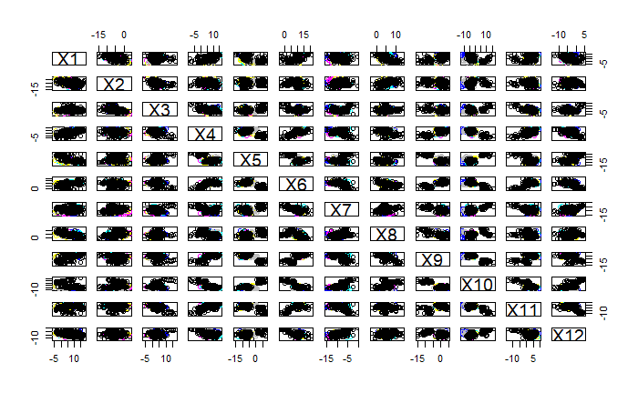

```r
  plot(x, col=3+as.numeric(y))
```

We can ever look at just a few variables

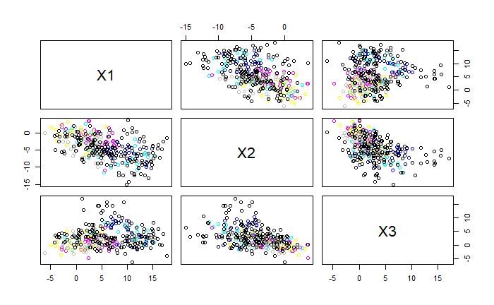

```r
plot(x[,1:3], col=3+as.numeric(y))
```

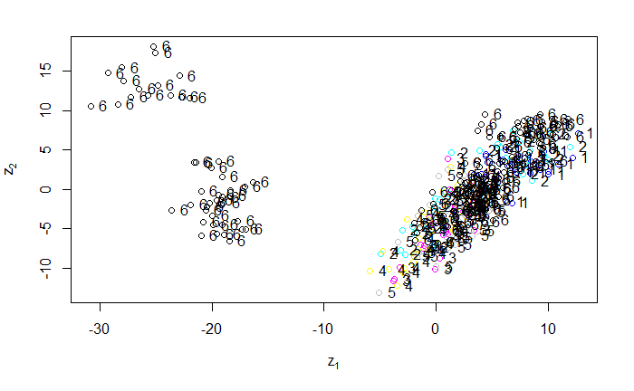

```r
  z <- predict(princomp(x), x)[,1:2]
  plot(z, col=3+as.numeric(y), xlab=expression(z[1]), ylab=expression(z[2]))
  text(z, labels=as.numeric(y), pos=4)
```

```r
  xy.pca <- data.frame(y, z)
  colnames(xy.pca) <- c('y', 'z1', 'z2')
```

How about a distribution of $Y$

```r
  prop.table(table(y))
```

```
y
        ES         FR         GE         IT         UK         US
0.08814590 0.09118541 0.09118541 0.09118541 0.13677812 0.50151976
```

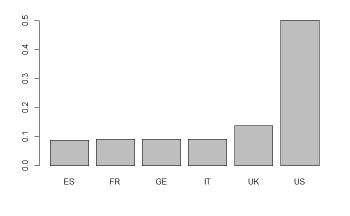

```r
  barplot(prop.table(table(y)))
```

What does a “US Speaker versus Non US Speaker” classification look like

```r
  y.us <- droplevels(as.factor(ifelse(y=='US','US','Non US')))
  prop.table(table(y.us))
```

```
y.us
   Non US        US
0.4984802 0.5015198
```

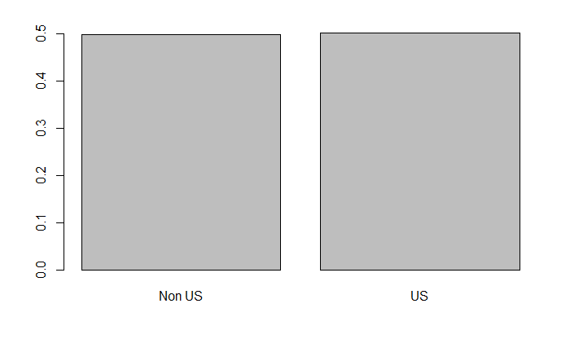

```r
  barplot(prop.table(table(y.us)))
```

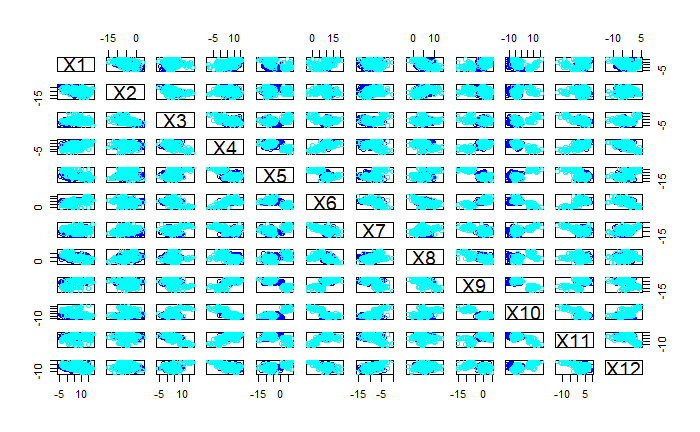

```r
  plot(x, col=3+as.numeric(y.us))
```

```r
  length(y.us)
```

```
[1] 329
```

```r
  length(y)
```

```
[1] 329
```

```r
  nrow(x)
```

```
[1] 329
```

```r
  head(x)
```

|  | X1 | X2 | X3 | X4 | X5 | X6 | X7 | X8 | X9 | X10 | X11 | X12 |
| --- | --- | --- | --- | --- | --- | --- | --- | --- | --- | --- | --- | --- |
| 1 | 7.071476 | -6.512900 | 7.650800 | 11.150783 | -7.657312 | 12.484021 | -11.70977 | 3.426596 | 1.4627152 | -2.812753 | 0.8665378 | -5.244274 |
| 2 | 10.982967 | -5.157445 | 3.952060 | 11.529381 | -7.638047 | 12.136098 | -12.03625 | 3.491943 | 0.5954408 | -4.508811 | 2.3321470 | -6.221857 |
| 3 | 7.827108 | -5.477472 | 7.816257 | 9.187592 | -7.172511 | 11.715299 | -13.84721 | 4.574075 | -1.6875593 | -7.204041 | -0.0118469 | -6.463144 |
| 4 | 6.744083 | -5.688920 | 6.546789 | 9.000183 | -6.924963 | 11.710766 | -12.37439 | 6.169879 | -0.5447467 | -6.019237 | 1.3585595 | -6.356441 |
| 5 | 5.836843 | -5.326557 | 7.472265 | 8.847440 | -6.773244 | 12.677218 | -12.31506 | 4.416344 | 0.1934999 | -3.644812 | 2.1512386 | -6.816310 |
| 6 | 6.267089 | -4.227738 | 7.227741 | 10.069418 | -6.953871 | 9.384771 | -15.34154 | 6.718533 | -0.4509516 | -7.177585 | 2.5387129 | -3.550536 |

```r
NA
```

Let’s mess around more with UK vs US

```r
  id.anglo <- which(y=='US' | y =='UK')
  y.anglo  <- y[id.anglo]

  y.anglo <- as.factor(droplevels(y.anglo))

  prop.table(table(droplevels(y.anglo)))
```

```
       UK        US
0.2142857 0.7857143
```

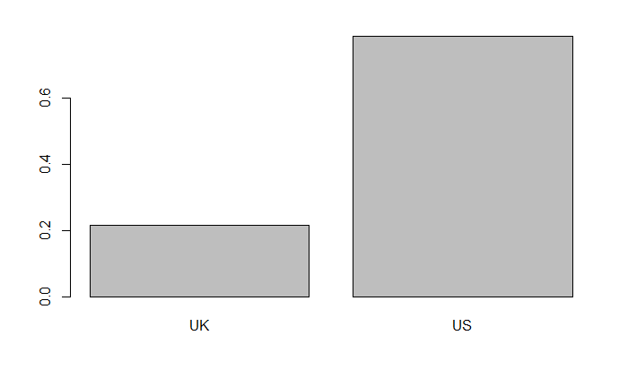

```r
  barplot(prop.table(table(droplevels(y.anglo))))
```

```r
  as.factor(droplevels(y.anglo))
```

```
  [1] UK UK UK UK UK UK UK UK UK UK UK UK UK UK UK UK UK UK UK UK UK UK UK UK UK UK UK UK
 [29] UK UK UK UK UK UK UK UK UK UK UK UK UK UK UK UK UK US US US US US US US US US US US
 [57] US US US US US US US US US US US US US US US US US US US US US US US US US US US US
 [85] US US US US US US US US US US US US US US US US US US US US US US US US US US US US
[113] US US US US US US US US US US US US US US US US US US US US US US US US US US US US
[141] US US US US US US US US US US US US US US US US US US US US US US US US US US US US
[169] US US US US US US US US US US US US US US US US US US US US US US US US US US US US
[197] US US US US US US US US US US US US US US
Levels: UK US
```

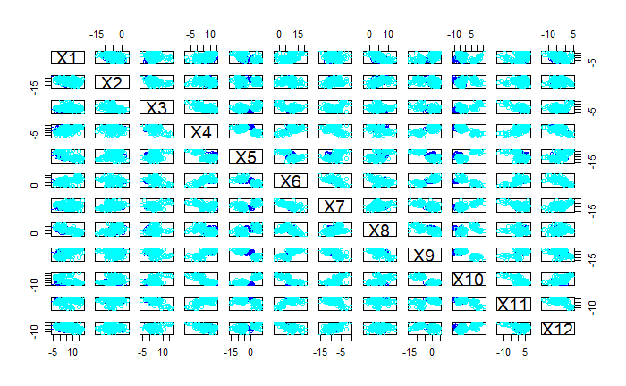

```r
  x.anglo <- x[id.anglo,]
  plot(x.anglo, col=3+as.numeric(y.anglo))
```

What would a tree look like

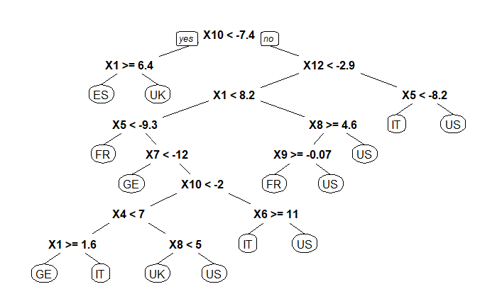

```r
  library(rpart)
  library(rpart.plot)
  tree.accent <- rpart(language~., data=xy)
  prp(tree.accent)
```

```r
  yhat.lda <-predict(lda(MFCC,y), MFCC)$class
  yhat.svm.C <- predict(ksvm(language~., data=xy, type='C-svc'), MFCC)
  yhat.svm.nu <- predict(ksvm(language~., data=xy, type='nu-svc'), MFCC)
  table(y,yhat.lda)
```

```
    yhat.lda
y     ES  FR  GE  IT  UK  US
  ES  24   0   0   0   2   3
  FR   0  12   0   4   0  14
  GE   0   0  19   1   0  10
  IT   0   0   1  21   1   7
  UK   2   2   0   4  30   7
  US   3   6   2   3   4 147
```

```r
  table(y,yhat.svm.C)
```

```
    yhat.svm.C
y     ES  FR  GE  IT  UK  US
  ES  26   0   0   0   0   3
  FR   0  25   0   0   0   5
  GE   0   0  20   1   0   9
  IT   0   0   1  24   0   5
  UK   0   0   0   2  37   6
  US   1   0   0   1   0 163
```

```r
  table(y,yhat.svm.nu)
```

```
    yhat.svm.nu
y     ES  FR  GE  IT  UK  US
  ES  28   0   0   0   0   1
  FR   0  29   0   0   0   1
  GE   0   0  20   1   0   9
  IT   0   0   0  26   0   4
  UK   0   0   0   0  43   2
  US   1   0   0   1   0 163
```

Now that we have a reasonably small size, we may perform some learning

```r
  n   <- nrow(xy)       # Sample size
  p   <- ncol(xy) - 1   # Dimensionality of the input space
  pos <- 1              # Position of the response
  colnames(xy)[pos] <- 'y'

  x   <- xy[,-pos]      # Data matrix: n x p matrix
  y   <- as.factor(xy[, pos])      # Response vector
  xy  <- data.frame(y,x)
  n; p
```

```
[1] 329
[1] 12
```

```r
  logistic.xy  <- glm(y~., data=xy, family=binomial(link='logit'))
  summary(logistic.xy)

  aic.logit.xy <- step(logistic.xy, scope=~., direction='both', k=2, trace=0)
  summary(aic.logit.xy)

  bic.logit.xy <- step(logistic.xy, scope=~., direction='both', k=log(n), trace=0)
  summary(bic.logit.xy)
```

[output not shown]

Focus on a single characteristic

```r
   par(mfrow=c(1,2))
   hist(xy$X10, prob=T)
   lines(density(xy$X10), lwd=2, col='red')
```

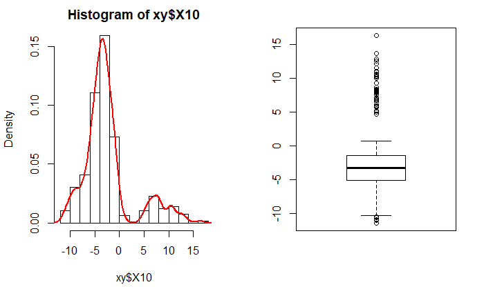

```r
   boxplot(xy$X10)
```

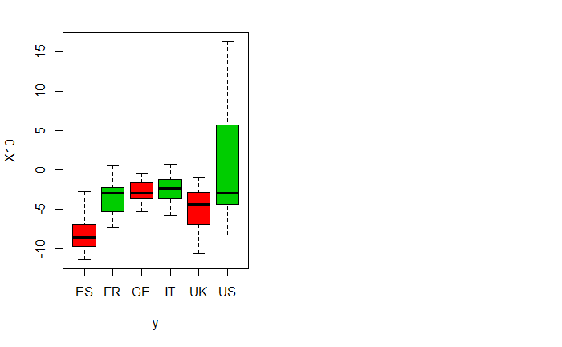

```r
   boxplot(X10~y, data=xy, col=2:3)
```

Let’s see even more

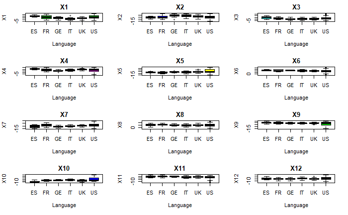

```r
  par(mfrow=c(4,3))
  for(j in 1:12)
  {
    boxplot(xy[,j+1]~y, data=xy, col=j+1+as.numeric(xy$y),
            main=colnames(xy)[j+1], ylab=colnames(xy)[j+1],
            xlab='Language')
  }
```

```r
  head(xy)
```

|  | y | X1 | X2 | X3 | X4 | X5 | X6 | X7 | X8 | X9 | X10 | X11 | X12 |
| --- | --- | --- | --- | --- | --- | --- | --- | --- | --- | --- | --- | --- | --- |
| 1 | ES | 7.071476 | -6.512900 | 7.650800 | 11.150783 | -7.657312 | 12.484021 | -11.70977 | 3.426596 | 1.4627152 | -2.812753 | 0.8665378 | -5.244274 |
| 2 | ES | 10.982967 | -5.157445 | 3.952060 | 11.529381 | -7.638047 | 12.136098 | -12.03625 | 3.491943 | 0.5954408 | -4.508811 | 2.3321470 | -6.221857 |
| 3 | ES | 7.827108 | -5.477472 | 7.816257 | 9.187592 | -7.172511 | 11.715299 | -13.84721 | 4.574075 | -1.6875593 | -7.204041 | -0.0118469 | -6.463144 |
| 4 | ES | 6.744083 | -5.688920 | 6.546789 | 9.000183 | -6.924963 | 11.710766 | -12.37439 | 6.169879 | -0.5447467 | -6.019237 | 1.3585595 | -6.356441 |
| 5 | ES | 5.836843 | -5.326557 | 7.472265 | 8.847440 | -6.773244 | 12.677218 | -12.31506 | 4.416344 | 0.1934999 | -3.644812 | 2.1512386 | -6.816310 |
| 6 | ES | 6.267089 | -4.227738 | 7.227741 | 10.069418 | -6.953871 | 9.384771 | -15.34154 | 6.718533 | -0.4509516 | -7.177585 | 2.5387129 | -3.550536 |

Single Linear Binary Logistic Regression

```r
  log.acc <- glm(y~X10, data=xy, family=binomial(link='logit'))
  summary(log.acc)
```

```
Call:
glm(formula = y ~ X10, family = binomial(link = "logit"), data = xy)

Deviance Residuals:
     Min        1Q    Median        3Q       Max
-2.95512   0.06722   0.16365   0.28271   1.83513

Coefficients:
            Estimate Std. Error z value Pr(>|z|)
(Intercept)   6.4548     0.7970   8.099 5.55e-16 ***
X10           0.7470     0.1106   6.752 1.46e-11 ***
---
Signif. codes:  0 ‘***’ 0.001 ‘**’ 0.01 ‘*’ 0.05 ‘.’ 0.1 ‘ ’ 1

(Dispersion parameter for binomial family taken to be 1)

    Null deviance: 196.23  on 328  degrees of freedom
Residual deviance: 111.92  on 327  degrees of freedom
AIC: 115.92

Number of Fisher Scoring iterations: 7
```

## Split of the data into training set and test set

```r
# Split the data

  set.seed (19671210)          # Set seed for random number generation to be reproducible

  epsilon <- 1/3               # Proportion of observations in the test set
  nte     <- round(n*epsilon)  # Number of observations in the test set
  ntr     <- n - nte
  id.tr   <- sample(sample(sample(n)))[1:ntr]   # For a sample of ntr indices from {1,2,..,n}
  #id .tr <- sample(1:n, ntr, replace=F)        # Another way to draw from {1,2,..n}
  id.te   <- setdiff(1:n, id.tr)
```

## Predictive performance of the 9-Nearest Neighbors Classifier

As you know by now, nearest neighbors learning machines are so-called lazy learners since there is no estimation per se in the traditional sense of storing a model. Instead, all the nearest neighbors machine does is perform predictions. If $\mathcal{Y}$ represents our output space and $\mathcal{X}$ represent our input space, and $\mathcal{V}_k(x)$ represents the set of the $k$ nearest neighbors of $x \in \mathcal{X}$ in the provided dataset $\mathcal{D}_n$, then the predicted class $\widehat{f}_{\tt kNN}(x)$ of $x \in \mathcal{X}$ is given by
$$\widehat{f}_{\tt kNN}(x) = \underset{c \in \mathcal{Y}}{{\tt argmax}}\Bigg\{\frac{1}{k}\sum_{i=1}^n{{\bf 1}(x_i \in \mathcal{V}_k(x)){\bf 1}(y_i=c)}\Bigg\}$$

```r
  library(class)
  k        <- 9
  y.te     <- y[id.te]                                 # True responses in test set
  y.te.hat <- knn(x[id.tr,], x[id.te,], y[id.tr], k=k) # Predicted responses in test set

  conf.mat.te <- table(y.te, y.te.hat)
  conf.mat.te
```

```
    y.te.hat
y.te ES FR GE IT UK US
  ES  7  0  0  0  0  2
  FR  0  4  0  0  1  0
  GE  0  0  6  2  1  2
  IT  0  1  0  6  0  0
  UK  0  1  0  1 11  4
  US  1  1  5  0  0 54
```

We now consider a different and very special nearest neighbors learning machines, namely the 1 nearest neighbor or simply nearest neighbor learning machine. This time we first consider only the training set, and generate the corresponding confusion matrix

```r
  library(class)
  k        <- 1
  y.tr     <- y[id.tr]                                 # True responses in test set
  y.tr.hat <- knn(x[id.tr,], x[id.tr,], y[id.tr], k=k) # Predicted responses in test set

  conf.mat.tr <- table(y.tr, y.tr.hat)
  conf.mat.tr
```

```
    y.tr.hat
y.tr  ES  FR  GE  IT  UK  US
  ES  20   0   0   0   0   0
  FR   0  25   0   0   0   0
  GE   0   0  19   0   0   0
  IT   0   0   0  23   0   0
  UK   0   0   0   0  28   0
  US   0   0   0   0   0 104
```

We can see above something quite remarkable in the confusion matrix.

## Exercise

Explain why the off diagonal have the values observed Generate the 1NN test set confusion matrix

Below we set alternative ways of generating the very same quantities encountered earlier. This is provided here just for completeness and one can choose any of the ways to generate the predictive quantities of interest

```r
# Indicator of error in test

  ind.err.te <- ifelse(y.te!=y.te.hat,1,0)      # Random variable tracking error. Indicator
  ind.err.te
```

```
  [1] 0 0 0 0 0 0 1 0 1 0 1 0 0 0 0 0 1 0 0 0 1 1 1 1 0 0 0 0 0 1 0 0 0 0 1 1 0 0 1 0 0 1
 [43] 0 0 0 1 1 0 0 0 0 0 0 1 0 0 1 1 0 0 0 0 0 0 0 0 0 0 0 0 0 0 0 0 0 0 0 0 0 0 0 0 0 0
 [85] 0 0 1 0 0 0 0 0 0 1 0 0 0 1 1 0 0 0 0 0 0 0 0 0 0 0
```

```r
# Identification of misclassified cases

  id.err     <- which(y.te!=y.te.hat)           # Which obs are misclassified
  id.err
```

```
 [1]  7  9 11 17 21 22 23 24 30 35 36 39 42 46 47 54 57 58 87 94 98 99
```

```r
# Confusion matrix

  conf.mat.te <- table(y.te, y.te.hat)
  conf.mat.te
```

```
    y.te.hat
y.te ES FR GE IT UK US
  ES  7  0  0  0  0  2
  FR  0  4  0  0  1  0
  GE  0  0  6  2  1  2
  IT  0  1  0  6  0  0
  UK  0  1  0  1 11  4
  US  1  1  5  0  0 54
```

```r
# Percentage of correctly classified (accurary)

  pcc.te <- sum(diag(conf.mat.te))/nte
  # pcc.te <- 1-mean(ind.err.te)        # Another way from ind.err.te
  # pcc.te <- 1-length(id.err.te)/nte   # Yet another way fr
  pcc.te
```

```
[1] 0.8
```

```r
# Test Error

  err.te <- 1-pcc.te                    # Complement of accurary
  err.te
```

```
[1] 0.2
```

$$\widehat{R}^{(tr)}(\widehat{f})= \frac{1}{|\mathcal{D}_n^{(tr)}|}\sum_{i=1}^n{{\bf 1}(z_i \in \mathcal{D}_n^{(tr)}){\tt loss}(y_i, \widehat{f}(x_i))}$$

The corresponding test error is

$$\widehat{R}^{(te)}(\widehat{f})= \frac{1}{|\mathcal{D}_n^{(te)}|}\sum_{i=1}^n{{\bf 1}(z_i \in \mathcal{D}_n^{(te)}){\tt loss}(y_i, \widehat{f}(x_i))}$$

Where we also crucially have

$$\mathcal{D}_n^{(tr)} \cup \mathcal{D}_n^{(te)} = \mathcal{D}_n$$

So that

$$|\mathcal{D}_n^{(tr)}| + |\mathcal{D}_n^{(te)}| = |\mathcal{D}_n| = n.$$

The loss function used in the above errors is simply the famous zero-one loss, namely
$${\tt loss}(y, f(x)) = {\tt zeroone}(y, f(x)) = {\bf 1}(y\neq f(x))=
\left\{
\begin{array}{ll}
1 & \text{if}\,\, y \neq f(x) \\
0 & \text{if}\,\, y = f(x)
\end{array}\right.$$

Let’s now focus on binary classification. First let’s do US vs NonUS speakers

```r
  xy <- data.frame(y.us, x)
  colnames(xy)[1] <- 'y'

  head(xy)
```

|  | y | X1 | X2 | X3 | X4 | X5 | X6 | X7 | X8 | X9 | X10 | X11 | X12 |
| --- | --- | --- | --- | --- | --- | --- | --- | --- | --- | --- | --- | --- | --- |
| 1 | Non US | 7.071476 | -6.512900 | 7.650800 | 11.150783 | -7.657312 | 12.484021 | -11.70977 | 3.426596 | 1.4627152 | -2.812753 | 0.8665378 | -5.244274 |
| 2 | Non US | 10.982967 | -5.157445 | 3.952060 | 11.529381 | -7.638047 | 12.136098 | -12.03625 | 3.491943 | 0.5954408 | -4.508811 | 2.3321470 | -6.221857 |
| 3 | Non US | 7.827108 | -5.477472 | 7.816257 | 9.187592 | -7.172511 | 11.715299 | -13.84721 | 4.574075 | -1.6875593 | -7.204041 | -0.0118469 | -6.463144 |
| 4 | Non US | 6.744083 | -5.688920 | 6.546789 | 9.000183 | -6.924963 | 11.710766 | -12.37439 | 6.169879 | -0.5447467 | -6.019237 | 1.3585595 | -6.356441 |
| 5 | Non US | 5.836843 | -5.326557 | 7.472265 | 8.847440 | -6.773244 | 12.677218 | -12.31506 | 4.416344 | 0.1934999 | -3.644812 | 2.1512386 | -6.816310 |
| 6 | Non US | 6.267089 | -4.227738 | 7.227741 | 10.069418 | -6.953871 | 9.384771 | -15.34154 | 6.718533 | -0.4509516 | -7.177585 | 2.5387129 | -3.550536 |

## Receiver Operating Characteristics (ROC) Curves

We now turn to the creation of the very appealing graphic summary known as the ROC curve. This is arguably one of the best tools in binary classification as it allows the straightforward and very intuitive graphical way of assessing the predictive performance of a binary classifier. The ROC curve is built from two main ingredients, namely the True Positive Rate (TPR) and the False Positive Rate (FPR). For a given estimated learning machine $\widehat{f}$, we have

$${\tt TPR}(\widehat{f}) = \Pr(\widehat{f}(X)= +1 | Y = +1) = \frac{\Pr(\widehat{f}(X)=+1 \, \text{and} \, Y = +1) }{\Pr(Y = + 1)}$$

and

$${\tt FPR}(\widehat{f}) = \Pr(\widehat{f}(X)= +1 | Y = -1) = \frac{\Pr(\widehat{f}(X)=+1 \, \text{and} \, Y = -1) }{\Pr(Y = - 1)}$$

In practice we neither have ${\tt FPR}(\widehat{f})$ nor ${\tt TPR}(\widehat{f})$, but instead their estimator $\widehat{{\tt FPR}(\widehat{f})}$ and $\widehat{{\tt TPR}(\widehat{f})}$ respectively.

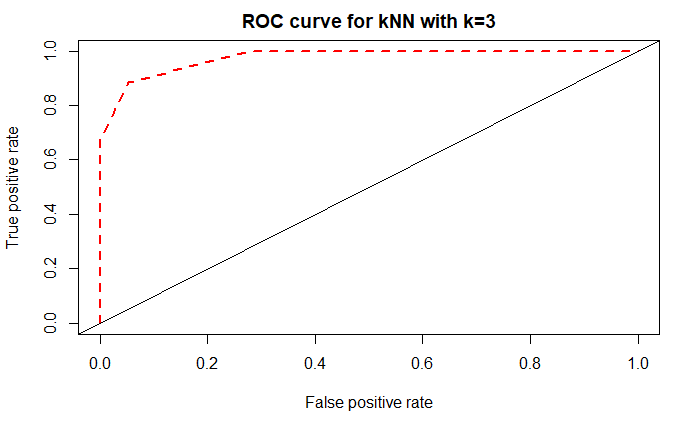

```r
#
#  ROC Curve: Plotting one single ROC Curve
#
  library(ROCR)

  y.roc   <- ifelse(y=='US',1,0)

  kNN.mod <- class::knn(x[id.tr,], x[id.tr,], y.roc[id.tr], k=3, prob=TRUE)
  prob    <- attr(kNN.mod, 'prob')
  prob    <- 2*ifelse(kNN.mod == "0", 1-prob, prob) - 1

  pred.knn <- prediction(prob, y.roc[id.tr])
  perf.knn <- performance(pred.knn, measure='tpr', x.measure='fpr')

  plot(perf.knn, col=2, lwd= 2, lty=2, main=paste('ROC curve for kNN with k=3'))
  abline(a=0,b=1)
```

We now consider the creation of the ROC curves of our binary classifiers, but this time based on the training set

```r
#
# Comparative ROC Curves on the training set
#
  library(ROCR)

  pos     <- 1
  y       <- xy[, pos]
  x       <- xy[,-pos]
  y.roc   <- ifelse(y=='US',1,0)

  kNN.mod <- class::knn(x[id.tr,], x[id.tr,], y.roc[id.tr], k=1, prob=TRUE)
  prob    <- attr(kNN.mod, 'prob')
  prob    <- 2*ifelse(kNN.mod == "0", 1-prob, prob) - 1

  pred.1NN <- prediction(prob, y.roc[id.tr])
  perf.1NN <- performance(pred.1NN, measure='tpr', x.measure='fpr')

  kNN.mod <- class::knn(x[id.tr,], x[id.tr,], y.roc[id.tr], k=13, prob=TRUE)
  prob    <- attr(kNN.mod, 'prob')
  prob    <- 2*ifelse(kNN.mod == "0", 1-prob, prob) - 1

  pred.13NN <- prediction(prob, y.roc[id.tr])
  perf.13NN <- performance(pred.13NN, measure='tpr', x.measure='fpr')

  kNN.mod <- class::knn(x[id.tr,], x[id.tr,], y.roc[id.tr], k=28, prob=TRUE)
  prob    <- attr(kNN.mod, 'prob')
  prob    <- 2*ifelse(kNN.mod == "0", 1-prob, prob) - 1

  pred.28NN <- prediction(prob, y.roc[id.tr])
  perf.28NN <- performance(pred.28NN, measure='tpr', x.measure='fpr')

  plot(perf.1NN, col=2, lwd= 2, lty=2, main=paste('Comparative ROC curves in Training'))
  plot(perf.13NN, col=3, lwd= 2, lty=3, add=TRUE)
  plot(perf.28NN, col=4, lwd= 2, lty=4, add=TRUE)
  abline(a=0,b=1)
  legend('bottomright', inset=0.05, c('1NN','13NN', '28NN'),  col=2:4, lty=2:4)
```

[output not shown]

```r
#
# Comparative ROC Curves on the test set
#
  library(ROCR)

  pos     <- 1
  y       <- xy[, pos]
  x       <- xy[,-pos]
  y.roc   <- ifelse(y=='US',1,0)

  kNN.mod <- class::knn(x[id.tr,], x[id.te,], y.roc[id.tr], k=1, prob=TRUE)
  prob    <- attr(kNN.mod, 'prob')
  prob    <- 2*ifelse(kNN.mod == "0", 1-prob, prob) - 1

  pred.1NN <- prediction(prob, y.roc[id.te])
  perf.1NN <- performance(pred.1NN, measure='tpr', x.measure='fpr')

  kNN.mod <- class::knn(x[id.tr,], x[id.te,], y.roc[id.tr], k=13, prob=TRUE)
  prob    <- attr(kNN.mod, 'prob')
  prob    <- 2*ifelse(kNN.mod == "0", 1-prob, prob) - 1

  pred.13NN <- prediction(prob, y.roc[id.te])
  perf.13NN <- performance(pred.13NN, measure='tpr', x.measure='fpr')

  kNN.mod <- class::knn(x[id.tr,], x[id.te,], y.roc[id.tr], k=28, prob=TRUE)
  prob    <- attr(kNN.mod, 'prob')
  prob    <- 2*ifelse(kNN.mod == "0", 1-prob, prob) - 1

  pred.28NN <- prediction(prob, y.roc[id.te])
  perf.28NN <- performance(pred.28NN, measure='tpr', x.measure='fpr')

  plot(perf.1NN, col=2, lwd= 2, lty=2, main=paste('Comparison of Predictive ROC curves'))
  plot(perf.13NN, col=3, lwd= 2, lty=3, add=TRUE)
```

```r
  plot(perf.28NN, col=4, lwd= 2, lty=4, add=TRUE)
  abline(a=0,b=1)
```

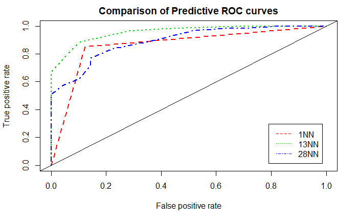

```r
  legend('bottomright', inset=0.05, c('1NN','13NN', '28NN'),  col=2:4, lty=2:4)
```

We see now from the above comparative ROC curves, that 1NN is no longer the winner. It’s apparent superior performance on the training set was most likely due to overfitting. This is an important lesson to learn, namely that one must base predictive comparisons on generalization which is mimic by the test set

### Comparing learning machines from different function spaces

```r
#
# Comparative ROC Curves on the test set
#
  library(ROCR)
  library(ipred)
  library(ada)
  library(adabag)
  library(kernlab)
  library(mboost)
  pos     <- 1
  y       <- xy[, pos]
  x       <- xy[,-pos]
  y.roc   <- ifelse(y=='US',1,0)

  # 1-Linear Discriminant Analysis

  lda.mod  <- lda(x[id.tr,], y.roc[id.tr])
  prob     <- predict(lda.mod, x[id.te,])$posterior[,2]
  pred.lda <- prediction(prob, y.roc[id.te])
  perf.lda <- performance(pred.lda, measure='tpr', x.measure='fpr')

  # 2-Quadratic Discriminant Analysis

  qda.mod  <- qda(x[id.tr,], y.roc[id.tr])
  prob     <- predict(qda.mod, x[id.te,])$posterior[,2]
  pred.qda <- prediction(prob, y.roc[id.te])
  perf.qda <- performance(pred.qda, measure='tpr', x.measure='fpr')


  # 3-Logistic Regression

  log.mod  <- glm(y~., data=xy[id.tr, ], family=binomial(link='logit'))
  prob     <- predict(log.mod, x[id.te,], type='response')  # Probabilities as prediction
  pred.log <- prediction(prob, y.roc[id.te])
  perf.log <- performance(pred.log, measure='tpr', x.measure='fpr')

  # 4-Naive Bayes
  library(naivebayes)
  naive.mod  <- naive_bayes(y~., data=xy[id.tr, ])
  prob       <- predict(naive.mod, x[id.te,], type='prob')[,2]  # Probabilities as prediction
  pred.naive <- prediction(prob, y.roc[id.te])
  perf.naive <- performance(pred.naive, measure='tpr', x.measure='fpr')

  # 5-Nearest Neighbors Learning Machine
  kNN.mod   <- class::knn(x[id.tr,], x[id.te,], y.roc[id.tr], k=12, prob=TRUE)
  prob      <- attr(kNN.mod, 'prob')
  prob      <- 2*ifelse(kNN.mod == "0", 1-prob, prob) - 1
  pred.kNN <- prediction(prob, y.roc[id.te])
  perf.kNN <- performance(pred.kNN, measure='tpr', x.measure='fpr')

  # 6-Support Vector Machines

  svm.mod  <- ksvm(y~., data=xy[id.tr, ], kernel='rbfdot', type='C-svc', prob.model=TRUE)
  prob     <- predict(svm.mod, x[id.te, ], type='probabilities')[,2]
  pred.svm <- prediction(prob, y.roc[id.te])
  perf.svm <- performance(pred.svm, measure='tpr', x.measure='fpr')

  # 7-Classification Trees

  tree.mod  <- rpart(y~., data=xy[id.tr, ])
  prob      <- predict(tree.mod, x[id.te, ], type='prob')[,2]
  pred.tree <- prediction(prob, y.roc[id.te])
  perf.tree <- performance(pred.tree, measure='tpr', x.measure='fpr')
  # 8-Random Forest

  library(randomForest)
  rf.mod    <- randomForest(y~., data=xy[id.tr, ])
  prob      <- predict(rf.mod, x[id.te, ], type='prob')[,2]
  pred.rf   <- prediction(prob, y.roc[id.te])
  perf.rf   <- performance(pred.rf, measure='tpr', x.measure='fpr')

  # 9-Stochastic Adaptive Boosting

  boost.mod   <- ada(y~., data=xy[id.tr, ])
  prob        <- predict(boost.mod, x[id.te, ], type='probs')[,2]
  pred.boost  <- prediction(prob, y.roc[id.te])
  perf.boost  <- performance(pred.boost, measure='tpr', x.measure='fpr')

  # 10-Gaussian Processes

  gp.mod    <- gausspr(y~., data=xy[id.tr, ], type='classification', kernel='rbfdot')
```

```
Using automatic sigma estimation (sigest) for RBF or laplace kernel
```

```r
  prob      <- predict(gp.mod, x[id.te, ], type='prob')[,2]
  pred.gp   <- prediction(prob, y.roc[id.te])
  perf.gp   <- performance(pred.gp, measure='tpr', x.measure='fpr')

  plot(perf.lda, col=2, lwd= 2, lty=1, main=paste('Comparison of Predictive ROC curves'))
  plot(perf.qda, col=3, lwd= 2, lty=1, add=TRUE)
```

```r
  plot(perf.log, col=4, lwd= 2, lty=1, add=TRUE)
  plot(perf.naive, col=5, lwd= 2, lty=1, add=TRUE)
```

```r
  plot(perf.kNN, col=6, lwd= 2, lty=1, add=TRUE)
  plot(perf.svm, col=7, lwd= 2, lty=1, add=TRUE)
```

```r
  plot(perf.tree, col=8, lwd= 2, lty=1, add=TRUE)
  plot(perf.rf, col=9, lwd= 2, lty=1, add=TRUE)
```

```r
  plot(perf.boost, col=10, lwd= 2, lty=1, add=TRUE)
  plot(perf.gp, col=11, lwd= 2, lty=1, add=TRUE)
```

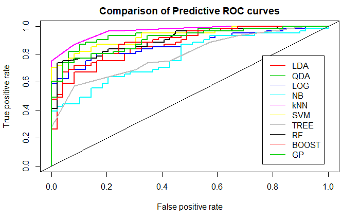

```r
  abline(a=0,b=1)
  legend('bottomright', inset=0.05, c('LDA','QDA', 'LOG', 'NB', 'kNN','SVM','TREE', 'RF','BOOST','GP'),
         col=2:11, lty=1)
```

## Cross Validation for Selection Models within a Function Space

Within the implicit function space from which each of the k Nearest Neighbors machines are chosen, it is of great interest to find a strategy or a least a criterion for choosing a member of the space, in this case the size of the neighborhood $k$. It turns out that cross validation does allow us to determine the neighborhood size $k$.

$${\tt CV}(\widehat{f}) = \frac{1}{V}\sum_{v=1}^{V}{\widehat{e}_v(\widehat{f})}$$
where the $v^{th}$ cross validated error $\widehat{e}_v(\widehat{f})$, is the error made by $\widehat{f}$ on the $v^{th}$ chunk of the $\mathcal{D}_n$, with that left out chunk not having been used in the training of $\widehat{f}$, ie
$$\widehat{e}_v(\widehat{f}) = \frac{1}{|\mathcal{D}_n^{(v)}|}\sum_{i=1}^n{\mathbf{1}(z_i \in \mathcal{D}_n^{(v)}){\tt loss}(y_i,\widehat{f}^{(-v)}(x_i))}$$
where $z_i=(x_i, y_i)$ and $\widehat{f}^{(-v)}(\cdot)$ is estimator $\widehat{f}$ obtained on data without the $v^{th}$ chunk $\mathcal{D}_n^{(v)}$.

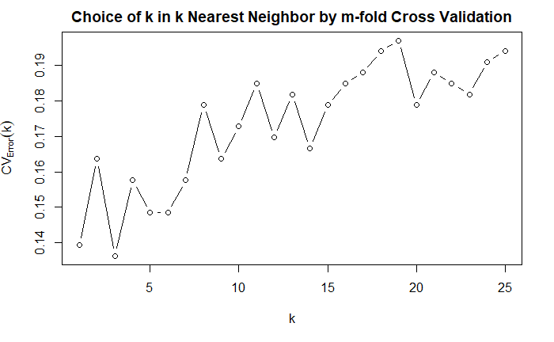

```r
  xtr <- x #x[id.tr,]          # Using the only the training for validation
  ytr <- y #y[id.tr]           # We could use the entire sample but that's greedy

  vK <- seq(1, 25, by=1)    # Grid of values of k
  nK <- length(vK)          # Number of values of k considered
  cv.error <-numeric(nK)    # Vector of cross validation errors for each k
  nc <- nrow(xtr)           # Number of observations used for cross validation
  c   <- 10                 # Number of folds. We are doing c-fold cross validation

  S   <- sample(sample(nc)) # We randomly shuffle the data before starting CV
  m   <- ceiling(nc/c)      # Maximum Number of observations in each fold

  held.out.set <- matrix(0, nrow=c, ncol=m) # Table used to track the evolution

  for(ic in 1:(c-1))
  {
    held.out.set[ic,] <- S[((ic-1)*m + 1):(ic*m)]
  }
  held.out.set[c, 1:(nc-(c-1)*m)] <- S[((c-1)*m + 1):nc]  # Handling last chunk just in case n!=mc
#
# Running the cross validation itself
#
  for(j in 1:nK)
  {
    for(i in 1:c)
    {
      out <-  held.out.set[i,]
      yhatc<- knn(xtr[-out,], xtr[out,],ytr[-out],  k=vK[j])
      cv.error[j]<-cv.error[j] + (length(out)-sum(diag(table(ytr[out],yhatc))))/length(out)
    }
    cv.error[j]<-cv.error[j]/c
  }
#
# Plot the cross validation curve
#
  plot(vK, cv.error, xlab='k', ylab=expression(CV[Error](k)),
      main='Choice of k in k Nearest Neighbor by m-fold Cross Validation')
  lines(vK, cv.error, type='c')
```

For a nicer looking plot, we resort to the famous ggplot

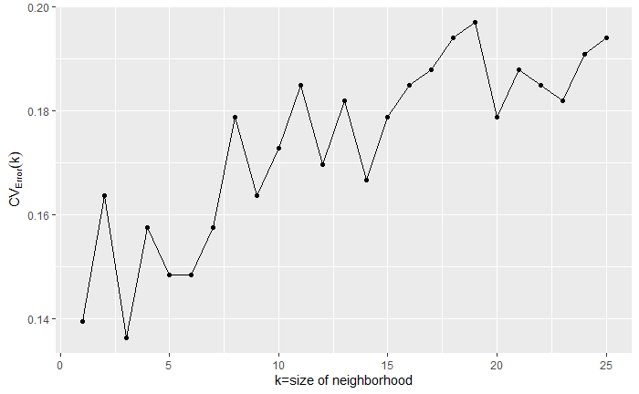

```r
#
#  Nicer plot with ggplot2
#

  cv <- data.frame(vK, cv.error)
  colnames(cv) <- c('k','error')

  ggplot(cv, aes(k,error))+geom_point()+geom_line()+
    labs(x='k=size of neighborhood', y=expression(CV[Error](k)))
```

## Predictive performance using stochastic hold out

Once members of various function spaces are chosen using perhaps cross validation as above, it becomes interesting to compare several methods via many copies of their test errors generated randomly via stochastic hold out. We first do it for a single learning machine and then we move on to several different learning machines

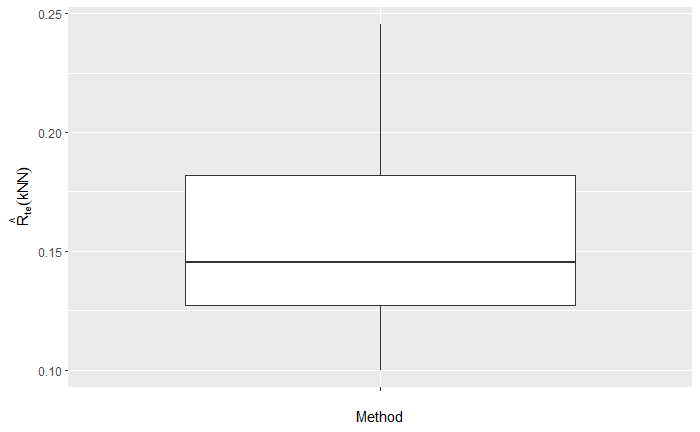

```r
#
# Extract the optimal k yielded by cross validation
#
  k.opt.cv <- 5 #max(which(cv.error==min(cv.error)))

##############################################################
# Using the optimally tuned k let's estimate the test error  #
##############################################################

  set.seed (19671210)          # Set seed for random number generation to be reproducible

  epsilon <- 1/3               # Proportion of observations in the test set
  nte     <- round(n*epsilon)  # Number of observations in the test set
  ntr     <- n - nte

  #k.opt.cv <- 28

  R <- 100   # Number of replications
  test.err <- numeric(R)

  for(r in 1:R)
  {
    # Split the data

    id.tr   <- sample(sample(sample(n)))[1:ntr]                   # For a sample of ntr indices from {1,2,..,n}
    id.te   <- setdiff(1:n, id.tr)

    y.te         <- y[id.te]                                        # True responses in test set
    y.te.hat     <- knn(x[id.tr,], x[id.te,], y[id.tr], k=k.opt.cv) # Predicted responses in test set
    ind.err.te   <- ifelse(y.te!=y.te.hat,1,0)                      # Random variable tracking error. Indicator
    test.err[r]  <- mean(ind.err.te)
  }

  test <- data.frame(test.err)
  colnames(test) <- c('error')

  ggplot(test, aes(x='', y=error))+geom_boxplot()+
  labs(x='Method', y=expression(hat(R)[te](kNN)))
```

```r
  ##############################################################
  #  Predictively compare different kNN  learning machines     #
  ##############################################################
```

```r
  xy <- read.csv('accent-mfcc-data-1.csv', header=T)

  pos      <- 1
  colnames(xy)[pos] <- 'y'
  xy[,pos] <-  as.factor(ifelse(xy[,pos]=='US',1,0))
  y        <- xy[, pos]
  x        <- xy[,-pos]

  n <- nrow(x)
  p <- ncol(x)

  set.seed (19671210)          # Set seed for random number generation to be reproducible

  epsilon <- 1/3               # Proportion of observations in the test set
  nte     <- round(n*epsilon)  # Number of observations in the test set
  ntr     <- n - nte

  R <- 50   # Number of replications
  test.err <- matrix(0, nrow=R, ncol=10)

  library(class)

  for(r in 1:R)
  {
    # Split the data

    id.tr   <- sample(sample(sample(n)))[1:ntr]                   # For a sample of ntr indices from {1,2,..,n}

    id.te   <- setdiff(1:n, id.tr)
    y.te    <- y[id.te]                                        # True responses in test set

    # 1-Linear Discriminant Analysis

    lda.mod        <- lda(x[id.tr,], y[id.tr])
    y.te.hat       <- predict(lda.mod, x[id.te,])$class
    ind.err.te     <- ifelse(y.te!=y.te.hat,1,0)                      # Random variable tracking error. Indicator
    test.err[r,1]  <- mean(ind.err.te)

    # 2-Quadratic Discriminant Analysis

    qda.mod        <- qda(x[id.tr,], y[id.tr])
    y.te.hat       <- predict(qda.mod, x[id.te,])$class
    ind.err.te     <- ifelse(y.te!=y.te.hat,1,0)                      # Random variable tracking error. Indicator
    test.err[r,2]  <- mean(ind.err.te)

    # 3-Logistic Regression

    log.mod        <- glm(y~., data=xy[id.tr, ], family=binomial(link='logit'))
    y.te.hat       <- as.factor(ifelse(predict(log.mod, x[id.te,], type='response')>0.5,1,0))
    ind.err.te     <- ifelse(y.te!=y.te.hat,1,0)                      # Random variable tracking error. Indicator
    test.err[r,3]  <- mean(ind.err.te)

    # 4-Naive Bayes

    naive.mod      <- naive_bayes(y~., data=xy[id.tr, ])
    y.te.hat       <- predict(naive.mod, x[id.te,], type='class')
    ind.err.te     <- ifelse(y.te!=y.te.hat,1,0)                      # Random variable tracking error. Indicator
    test.err[r,4]  <- mean(ind.err.te)

    # 5-Nearest Neighbors Learning Machine
    y.te.hat       <- knn(x[id.tr,], x[id.te,], y[id.tr], k=1, prob=TRUE)
    ind.err.te     <- ifelse(y.te!=y.te.hat,1,0)                      # Random variable tracking error. Indicator
    test.err[r,5]  <- mean(ind.err.te)

    # 6-Support Vector Machines

    svm.mod        <- ksvm(y~., data=xy[id.tr, ], kernel='rbfdot', type='C-svc', prob.model=TRUE)
    y.te.hat       <- predict(svm.mod, x[id.te, ], type='response')
    ind.err.te     <- ifelse(y.te!=y.te.hat,1,0)                      # Random variable tracking error. Indicator
    test.err[r,6]  <- mean(ind.err.te)

    # 7-Classification Trees

    tree.mod       <- rpart(y~., data=xy[id.tr, ])
    y.te.hat       <- predict(tree.mod, x[id.te, ], type='class')
    ind.err.te     <- ifelse(y.te!=y.te.hat,1,0)                      # Random variable tracking error. Indicator
    test.err[r,7]  <- mean(ind.err.te)

    # 8-Random Forest

    rf.mod         <- randomForest(y~., data=xy[id.tr, ])
    y.te.hat       <- predict(rf.mod, x[id.te, ], type='response')
    ind.err.te     <- ifelse(y.te!=y.te.hat,1,0)                      # Random variable tracking error. Indicator
    test.err[r,8]  <- mean(ind.err.te)

    # 9-Stochastic Adaptive Boosting

    boost.mod      <- ada(y~., data=xy[id.tr, ])
    y.te.hat       <- predict(boost.mod, x[id.te, ], type='vector')
    ind.err.te     <- ifelse(y.te!=y.te.hat,1,0)
    test.err[r,9]  <- mean(ind.err.te)

    # 10-Gaussian Processes

    gp.mod         <- gausspr(y~., data=xy[id.tr, ], type='classification', kernel='rbfdot')
    y.te.hat       <- predict(gp.mod, x[id.te, ], type='response')
    ind.err.te     <- ifelse(y.te!=y.te.hat,1,0)
    test.err[r,10] <- mean(ind.err.te)
  }
```

[output not shown]

Let’s plot and see

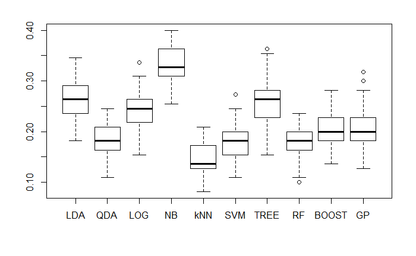

```r
  te.err <- data.frame(test.err)
  Method<-c('LDA','QDA', 'LOG', 'NB', 'kNN','SVM','TREE', 'RF','BOOST','GP')
  colnames(te.err) <- Method
  boxplot(te.err)
```

How about the nice ggplot version

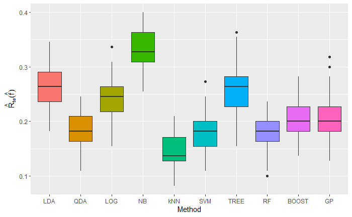

```r
  require(reshape2)
  ggplot(data = melt(te.err), aes(x=variable, y=value)) + geom_boxplot(aes(fill=variable))+
    labs(x='Method', y=expression(hat(R)[te](hat(f))))+
    theme(legend.position="none")
```

We can also explore the accuracy

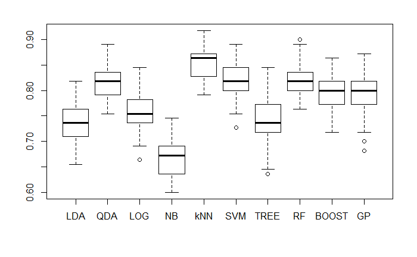

```r
  test.acc <- data.frame(1-test.err)
  Method<-c('LDA','QDA', 'LOG', 'NB', 'kNN','SVM','TREE', 'RF','BOOST','GP')
  colnames(test.acc) <- Method
  boxplot(test.acc)
```

Enjoying ggplot for accuracy

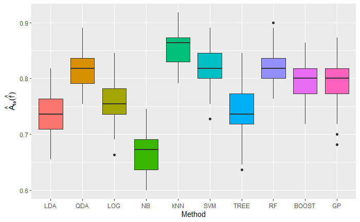

```r
  require(reshape2)
  ggplot(data = melt(test.acc), aes(x=variable, y=value)) + geom_boxplot(aes(fill=variable))+
    labs(x='Method', y=expression(hat(A)[te](hat(f))))+
    theme(legend.position="none")
```

## Analysis of Variance

From a purely statistical perspective, it often becomes important to perform the inferential method of analysis of variance to more rigorously and more formally compare the learning machines under consideration

```r
#
# Is the difference between the methods significant
#
  aov.method <- aov(value~variable, data=melt(te.err))
  anova(aov.method)
```

```
Analysis of Variance Table

Response: value
           Df  Sum Sq  Mean Sq F value    Pr(>F)
variable    9 1.39042 0.154492  113.77 < 2.2e-16 ***
Residuals 490 0.66536 0.001358
---
Signif. codes:  0 ‘***’ 0.001 ‘**’ 0.01 ‘*’ 0.05 ‘.’ 0.1 ‘ ’ 1
```

```r
  #summary(aov.method)

  TukeyHSD(aov.method, ordered = TRUE)
```

```
  Tukey multiple comparisons of means
    95% family-wise confidence level
    factor levels have been ordered

Fit: aov(formula = value ~ variable, data = melt(te.err))

$variable
                  diff           lwr        upr     p adj
RF-kNN     0.034727273  0.0113030083 0.05815154 0.0001378
SVM-kNN    0.036363636  0.0129393719 0.05978790 0.0000482
QDA-kNN    0.041818182  0.0183939174 0.06524245 0.0000011
BOOST-kNN  0.057636364  0.0342120992 0.08106063 0.0000000
GP-kNN     0.062363636  0.0389393719 0.08578790 0.0000000
LOG-kNN    0.095818182  0.0723939174 0.11924245 0.0000000
TREE-kNN   0.113818182  0.0903939174 0.13724245 0.0000000
LDA-kNN    0.122545455  0.0991211901 0.14596972 0.0000000
NB-kNN     0.190363636  0.1669393719 0.21378790 0.0000000
SVM-RF     0.001636364 -0.0217879008 0.02506063 1.0000000
QDA-RF     0.007090909 -0.0163333553 0.03051517 0.9941235
BOOST-RF   0.022909091 -0.0005151735 0.04633336 0.0613084
GP-RF      0.027636364  0.0042120992 0.05106063 0.0075133
LOG-RF     0.061090909  0.0376666447 0.08451517 0.0000000
TREE-RF    0.079090909  0.0556666447 0.10251517 0.0000000
LDA-RF     0.087818182  0.0643939174 0.11124245 0.0000000
NB-RF      0.155636364  0.1322120992 0.17906063 0.0000000
QDA-SVM    0.005454545 -0.0179697190 0.02887881 0.9992300
BOOST-SVM  0.021272727 -0.0021515372 0.04469699 0.1121518
GP-SVM     0.026000000  0.0025757356 0.04942426 0.0164369
LOG-SVM    0.059454545  0.0360302810 0.08287881 0.0000000
TREE-SVM   0.077454545  0.0540302810 0.10087881 0.0000000
LDA-SVM    0.086181818  0.0627575538 0.10960608 0.0000000
NB-SVM     0.154000000  0.1305757356 0.17742426 0.0000000
BOOST-QDA  0.015818182 -0.0076060826 0.03924245 0.4955974
GP-QDA     0.020545455 -0.0028788099 0.04396972 0.1434701
LOG-QDA    0.054000000  0.0305757356 0.07742426 0.0000000
TREE-QDA   0.072000000  0.0485757356 0.09542426 0.0000000
LDA-QDA    0.080727273  0.0573030083 0.10415154 0.0000000
NB-QDA     0.148545455  0.1251211901 0.17196972 0.0000000
GP-BOOST   0.004727273 -0.0186969917 0.02815154 0.9997603
LOG-BOOST  0.038181818  0.0147575538 0.06160608 0.0000142
TREE-BOOST 0.056181818  0.0327575538 0.07960608 0.0000000
LDA-BOOST  0.064909091  0.0414848265 0.08833336 0.0000000
NB-BOOST   0.132727273  0.1093030083 0.15615154 0.0000000
LOG-GP     0.033454545  0.0100302810 0.05687881 0.0003022
TREE-GP    0.051454545  0.0280302810 0.07487881 0.0000000
LDA-GP     0.060181818  0.0367575538 0.08360608 0.0000000
NB-GP      0.128000000  0.1045757356 0.15142426 0.0000000
TREE-LOG   0.018000000 -0.0054242644 0.04142426 0.3030957
LDA-LOG    0.026727273  0.0033030083 0.05015154 0.0116886
NB-LOG     0.094545455  0.0711211901 0.11796972 0.0000000
LDA-TREE   0.008727273 -0.0146969917 0.03215154 0.9745328
NB-TREE    0.076545455  0.0531211901 0.09996972 0.0000000
NB-LDA     0.067818182  0.0443939174 0.09124245 0.0000000
```

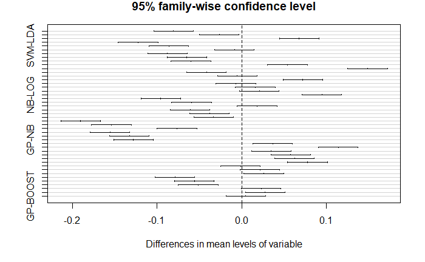

```r
  plot(TukeyHSD(aov.method))
```

The comparison in this case is trivial.